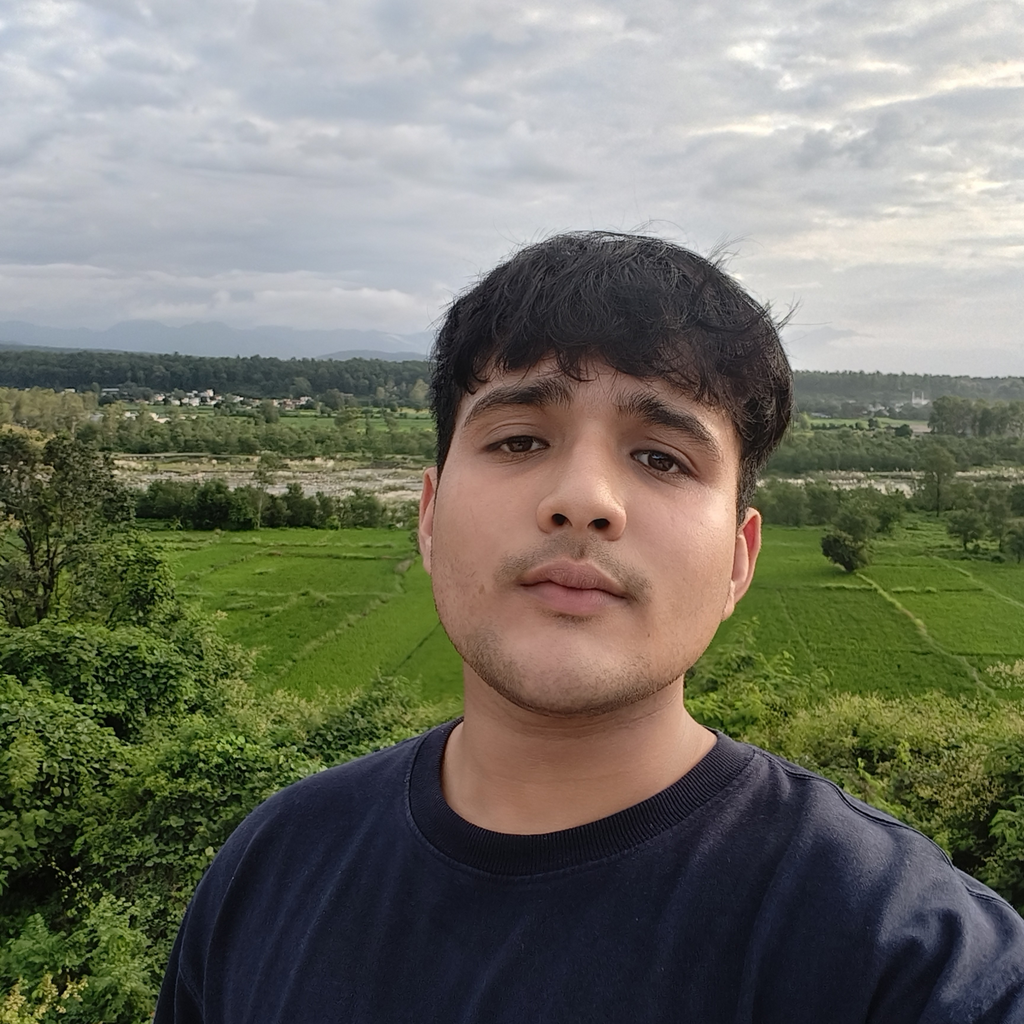

# Sumer Gupta

## Welcome!

My name is Sumer Gupta, and I’m a student at the University of Essex. This site is a digital repository for my work in quantitative political analysis, focusing on regression analysis and data visualization.

## Featured projects

### 1. 2024 UK General Election Turnout Analysis

**Overview**:

This project attempted to investigate the low voter turnout (59.7%) across the 650 constituencies observed the 2024 UK General Election and the factors behind them. By merging official candidacy data with geographical information, the analysis explores how voter engagement varies by nation and the structural “fairness” of representation in the British Parliament.

**Technical Skills**:

1. **Data Wrangling**: Cleaned the data-set, filtering out by-elections, standardized column naming, and calculated the registered turnout as a percentage of the total electorate.
2. *Statistical Analysis*: Calculated measures of inequality, including the range, variance and standard deviation to analyse the inequality between constituency sizes in the UK.
3. *Data Visualization*: Constructed violin plots and bar charts with 95% confidence intervals to compare the mean and median turnout across the four countries of the UK: England, Scotland, Wales and Northern Ireland. Then, I developed faceted density plots to normalize the distribution, which would allow for an easier, “apples-to-apples”, comparison of constituency sizes despite the vastly different number of constituencies in each countries.

**Key Insights**:

1. *Leaders*: England displayed the highest median turout (60.7%), while Wales showed the lowest turnout (56.8%)
2. *Inequality*:The largest constituency has 4.27 times more voters than the smallest, this calls into question the democratic principle of “one person, one vote”; if a country possesses a lower number of mean votes, then the average voter there has a greater voter-power. The analysis found that Welsh voters have the most voter-power, so on average, an MP in Wales is elected by a smaller voter base than an MP in any other country of the UK.
3. *Distribution*: Northern Ireland has the most equally sized constituencies, while Scotland has the most unequally sized constituencies, this is characterized by the voters in remote and sparsely populated areas. This implies that Northern Ireland maintains a the principle of “one person, one vote” across its districts, while Scotland’s geography makes necessary significant deviations from that principle to ensure equal representation for more isolated communities.

View Project →

### 2. A/B Testing in Political Communication

**Overview**:

This project simulated a randomized controlled trial to evaluate the effectiveness of different forms of digital political messaging. I compared a “standard” (control) website homepage to an “issue-focused” (treatment) website homepage to investigate which homepage design more effectively converts website visitors into registered party supporters. I then estimated the causal impact of targeted messaging on the probability that a visitor will sign up as a party supporter.

**Technical Skills**:

1. **Simulating an Experiment**: Generated a synthetic data-set to represent website traffic and simulating random assignment to the control and treatment homepages.
2. *ATE Estimation*: Estimated the average treatment effect (ATE) using a linear probability model (LPM).
3. *Interaction Modelling*: Engineered an interaction term between the treatment and age of visitor to identify heterogeneous effects. This enabled me to determine whether the issue-focused homepage resonated more strongly with certain age groups.
4. *Data Visualization*: Constructed a plot depicting the marginal effects of treatment on age to visualize how the impact of the homepage design diverges as voters grow older.

**Key Insights**:

1. *Age Gap*: The issue-focused homepage was significantly more effective for older website visitors, while younger visitors showed higher baseline engagement with the standard homepage.
2. *Targeting*: The graph showing the treatment effect on age shows that an age-stratified communication strategy will be more efficient than a “one size fits all” strategy.

View Project →

### 3. Text Analysis of Inaugural Addresses

**Overview:**

This project applied quantitative text analysis to the US Presidential Inaugural Addresses from 1861 to 2021 to investigate whether partisan language patterns can be detected statistically. Using the `quanteda` ecosystem, I build a full text-as-data pipeline - from constructing a raw corpus to supervised classification - in order to predict the party affiliation of a politician purely from the vocabulary of their speech.

**Technical Skills:**

1. *Corpus Construction*: Built and annotated a corpus of 40 inaugural addresses using the built-in `quanteda` dataset, then reshaped the raw text into paragraph-level observations, increased the data points to enable a more granular statistical classification.
2. *Text Processing*: Applied a rigorous reprocessing pipeline that involved tokenisation, stemming and stopward removal to convert raw prose into a structured Document-Feature Matrix (DFM) that is ready for analysis.
3. *Keyness Analysis*: Identified the specific “marker words” that define partisan rhetoric using chi-squared keyness statistics which allowed for a data-driven comparison of the vocabulary most closely associated with Democrat versus Republican inaugural addresses.
4. *Supervised Classification*: Trained a multinomial Naïve Bayes classifier, with Laplace smoothing, so that the categorisation of political text is automated. The predicted accuracy of the model is evaluated using industry-standard metrics, this include precision, recall and F1-score, on a test set.

**Key Insights:**

1. *Predictive Asymmetry*: While the model had higher precision for Republican labels, it showed better recall for democratic paragraphs. This suggests that while certain Republican markers are more distinct, the model captured a broader and less precise share of the Democrat rhetoric.
2. *Subtle Patterns*: Even though keyness analysis showed distinct partisan vocabularies, these patterns proved to be too subtle for classification at the paragraph level.
3. *Predictive Power*: The classifier achieved an accuracy of 58.3% which was only marginally better than the 55.7% “No Information Rate”. The p-value of 0.19 suggests that the model cannot reliably outperform a baseline guess on the basis of the most frequent party.

View Project →

Built with [Postcards](https://github.com/seankross/postcards) & [Distill](https://rstudio.github.io/distill/%3E) for R Markdown